# Rapport de groupe en Sciences des Données 2 + Bases de données

## Réponses aux Questions à l’aide de R

On utilise la fonction summary pour obtenir un résumé statistique des données sur nos entreprises. Cela nous permettra d’avoir rapidement un aperçu sur les données tel que les chiffres d’affaires des entreprises en 2022 qui nous intéresse ici. **Resumé des données:**

[figure not shown]

Voici un résumé des informations obtenues à partir de l’analyse des chiffres d’affaires des entreprises en 2022 :

- La **moyenne** de chiffre d’affaires en 2022 est de **24 971 661 euros**. Cela signifie que si l’on additionne tous les chiffres d’affaires de toutes les entreprises et que l’on divise cette somme par le nombre total d’entreprises, on obtient une moyenne de 24 971 661. Cependant, il est important de noter que la moyenne peut être biaisée par des valeurs extrêmes (appelées “outliers”), ce qui peut fausser la représentativité de cette mesure. C’est pourquoi il ce serait mieux d’utiliser d’autres mesures de tendance centrale en combinaison avec la moyenne, comme la médiane ou le mode.
- Le chiffre d’affaires **minimum** est **de 0 euro**, ce qui pourrait être dû à des entreprises qui n’ont pas généré de revenus au cours de cette période.
- Le **premier quartile** est de **691 914 euros**, ce qui signifie que **25%** des entreprises ont un chiffre d’affaires inférieur à ce montant.
- La **médiane**, qui est la valeur au milieu de la distribution, est de **3 574 482 euros**. Cela signifie que 50% des entreprises ont un chiffre d’affaires inférieur à ce montant et 50% ont un chiffre d’affaires supérieur.
- Le **troisième quartile** est de **15 836 456 euros**, ce qui signifie que 75% des entreprises ont un chiffre d’affaires inférieur à ce montant.
- La valeur **maximale** de chiffre d’affaires est de **2 909 072 591 euros**, ce qui représente l’entreprise ayant généré le plus de revenus en **2022**.

**1)Quels sont les secteurs d’activités qui ont enregistré la plus forte croissance entre 2020 et 2022 ?**

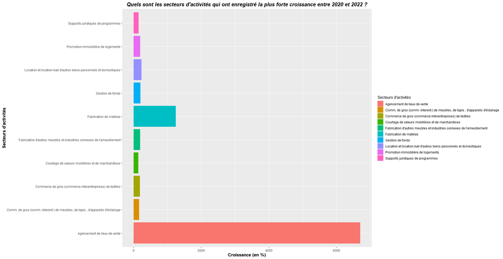

Le graphique affiche les 10 secteurs d’activités avec la plus forte croissance de revenus entre 2020 et 2022 en France. Comme nous pouvons le voir sur le graphique, parmi les 10 secteurs d’activités avec le taux de croissance le plus élevé, 2 secteurs prédominent. Le secteur de **fabrication de matelas** a enregistré une croissance d’environ **1249%** entre 2020 et 2022 mais c’est surtout le secteur **d’agencement de lieux de vente** qui a connu une forte augmentation du taux de croissance d’environ **6705%** sur la même période. Cela est probablement du à la crise du Covid-19 qui a eu lieu en 2020.

**2)Dans quelles régions se trouvent les secteurs d’activités ayant enregistré la plus forte croissance de chiffre d’affaires entre 2020 et 2022?**

[figure not shown]

Diagramme en barre.

Ce graphe permet de répondre à la question “Dans quelle région se trouvent les secteurs d’activités ayant enregistré la plus forte croissance de chiffre d’affaires au cours des trois dernières années(2020 à 2022)?”. Il affiche la répartition par région sous forme de diagramme en barre avec la croissance du CA en tant que poids. Cela permet de visualiser les régions où les secteurs d’activités connaissant la croissance la plus rapide en termes de CA et de comprendre les tendances et les opportunités de croissance potentielles pour les entreprises dans ces régions et secteurs.

**3)Quels sont les secteurs d’activités qui ont enregistré les plus gros chiffres d’affaires au cours des trois dernières années?**

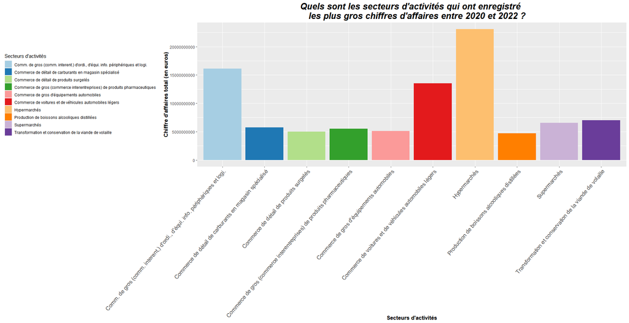

Le graphique affiche les 10 secteurs d’activités avec les plus gros chiffres d’affaires entre 2020 et 2022 en France. Nous remarquons sur le graphique, 3 secteurs d’activités qui ont accumulé plus de 10 milliards d’euros de chiffres d’affaires entre 2020 et 2022. Le **commerce de voitures et de véhicules automobile** a engendré plus de **13 milliards d’euros** durant cette période. Quant au commerce de gros d’ordinateurs, d’équipements informatiques, il a amené plus de **16 milliards d’euros** de chiffre d’affaires. Les **hypermarchés** sont les premiers secteurs d’activités, ils ont rapporté plus de **23 milliards d’euros** de chiffre d’affaires en France ces 3 dernières années.

**4)Dans quelles régions se trouvent les secteurs d’activités ayant enregistré les plus gros chiffres d’affaires au cours des trois dernières années?**

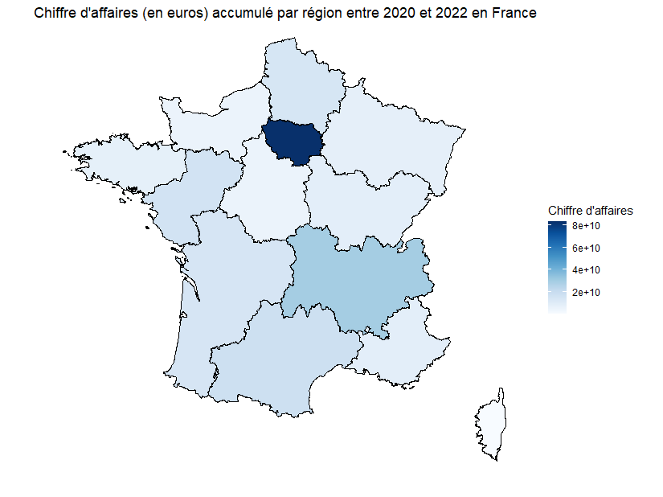

Carte.

Le graphique montre les différentes régions de France selon le chiffre d’affaires qu’elles ont obtenu. La deuxième région qui a accumulé le plus de chiffres d’affaires est la région **Auvergne-Rhône-Alpes** qui a généré plus de **29 milliars d’euros** entre 2020 et 2022. C’est beaucoup moins que la région **Île-de-France (bleu foncé sur le graphique)** qui a engendré environ **84 milliars d’euros** de chiffres d’affaires soit presque 3 fois plus que la région **Auvergne-Rhône-Alpes**. **NB**: Nous avons laissé seulement la France métropolitaine pour avoir un graphique plus clair.

# Annexes

## **Codes**

**1)Quels sont les secteurs d’activités qui ont enregistré la plus forte croissance entre 2020 et 2022 ?**

```r
requete1 <- "SELECT secteur_activite,
((total_ca_2022 - total_ca_2020)/total_ca_2020)*100 AS croissance
FROM table_activite
ORDER BY croissance DESC
LIMIT 10;"
requete1
View(requete1)
data1 <- dbGetQuery(bd, requete1)

ggplot(data1) +
  aes(
    x = secteur_activite,
    fill = secteur_activite,
    weight = croissance
  ) +
  geom_bar(position = "dodge") +
  scale_fill_hue(direction = 1) +
  labs(
    x = "Secteurs d'activités",
    y = "Croissance (en %)",
    title = "Quels sont les secteurs d'activités qui ont enregistré la plus forte croissance entre 2020 et 2022 ?",
    fill = "Secteurs d'activités"
  ) +
  coord_flip() +
  theme_gray() +
  theme(
    plot.title = element_text(size = 15L,
                              face = "bold.italic",
                              hjust = 0.5),
    axis.title.y = element_text(size = 13L,
                                face = "bold"),
    axis.title.x = element_text(size = 13L,
                                face = "bold")
  )
```

**2)Dans quelles régions se trouvent les secteurs d’activités ayant enregistré la plus forte croissance de chiffre d’affaires entre 2020 et 2022?**

```r
   diagramme = ggplot(data3) +
  aes(
    x = nom_region,
    fill = secteur_Activite,
    weight = croissance
  ) +
  geom_bar(position = "dodge") +
  scale_fill_hue(direction = 1) +
  labs(
    x = "Région",
    y = "Croissance du CA en millons d'euros",
    title = "Titre: Dans quelle région se trouvent les secteurs d'activités
    ayant enregistré la plus forte croissance de chiffre d'affaires entre
    2020 et 2022?",
    fill = "Secteur d'activite"
  ) +
  theme_gray() +
  theme(
    plot.title = element_text(face = "bold.italic"),
    plot.subtitle = element_text(size = 14L,
    face = "italic",
    hjust = 0.5),
    axis.title.y = element_text(size = 18L,
    face = "bold.italic"),
    axis.title.x = element_text(size = 18L,
    face = "bold.italic")
  )
```

**3)Quels sont les secteurs d’activités qui ont enregistré les plus gros chiffres d’affaires au cours des trois dernières années?**

```r
requete2 <- SELECT secteur_activite, SUM(total_ca_2020) + SUM(total_ca_2021) + SUM(total_ca_2022) AS chiffre_affaires_total
FROM table_activite
GROUP BY secteur_activite
ORDER BY chiffre_affaires_total DESC
LIMIT 10;
requete2
View(requete2)
data2 <- dbGetQuery(bd, requete2)
colors <- brewer.pal(10, "Paired")
ggplot(data2) +
  aes(
    x = secteur_activite,
    fill = secteur_activite,
    weight = chiffre_affaires_total
  ) +
  geom_bar() +
  scale_fill_manual(
    values = colors
  ) +
  labs(
    x = "Secteurs d'activités",
    y = "Chiffre d'affaires total (en euros)",
    title = "Quels sont les secteurs d'activités qui ont enregistré
    les plus gros chiffres d'affaires entre 2020 et 2022 ?",
    fill = "Secteurs d'activités"
  ) +
  theme_gray() +
  theme(
    plot.title = element_text(size = 15L,
                              face = "bold.italic",
                              hjust = 1.5),
    axis.title.y = element_text(size = 13L,
                                face = "bold"),
    axis.title.x = element_text(size = 13L,
                                face = "bold"),
    axis.text.x = element_text(angle = 50, hjust = 1),
    legend.position = "left", legend.justification = "center"
  )
```

## **Tables**

[output not shown]